# Delinquency in 1.7 million auto loans

T. Morrison

### Intro

This analysis was inspired by some news I heard on the radio recently regarding high auto loan delinquency rates. I decided to use this unique granular data to take a closer look.

### The data

More info on the nature of the data and auto ABS can be found in my prior piece [here](https://moman822.github.io/projects/abs/absee1.html).

At the time of this writing, ABS-EE disclosures have been made for January, 2019 by 29 ABS deals. According to my [tracker](https://moman822.github.io/abs-ee/absee.html), there are over 100 active auto ABS deals filing disclosures currently. The remaining deals will disclose later in the month. Only the January data will be used in this analysis.

Across all 29 deals, there are 1.7 million individual loans, a.k.a. receivables. Looking at some summary statistics and visualizations of the borrowers’ characteristics, these appear to be trending towards lower quality borrowers.

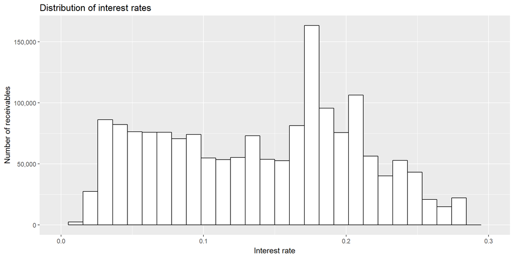

On interest rates, a quick search online suggests average interest rates of around 4-5 percent, so the mean (13.9%) and median (15%) rates in this sample are very high, indicating poor-quality borrowers.

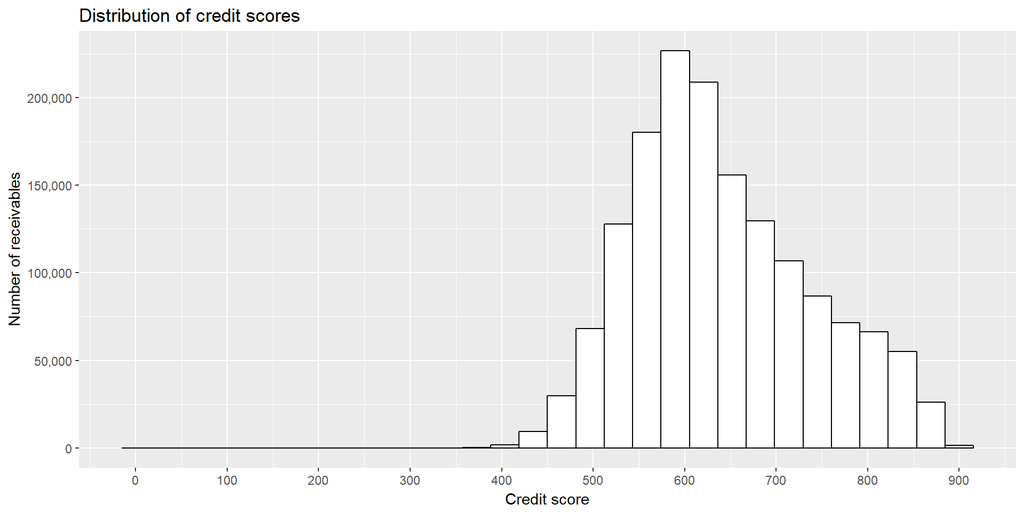

The mean (640) and median (622) credit scores fall in the subprime category.

Of the 1.7 million loans, about 10 percent were originated before 2016, while 82 percent were originated in 2017 or later. This distribution is a feature of when the ABS deals themselves were created (i.e., a deal created in January, 2017 could not have receivables originated later than December 2016).

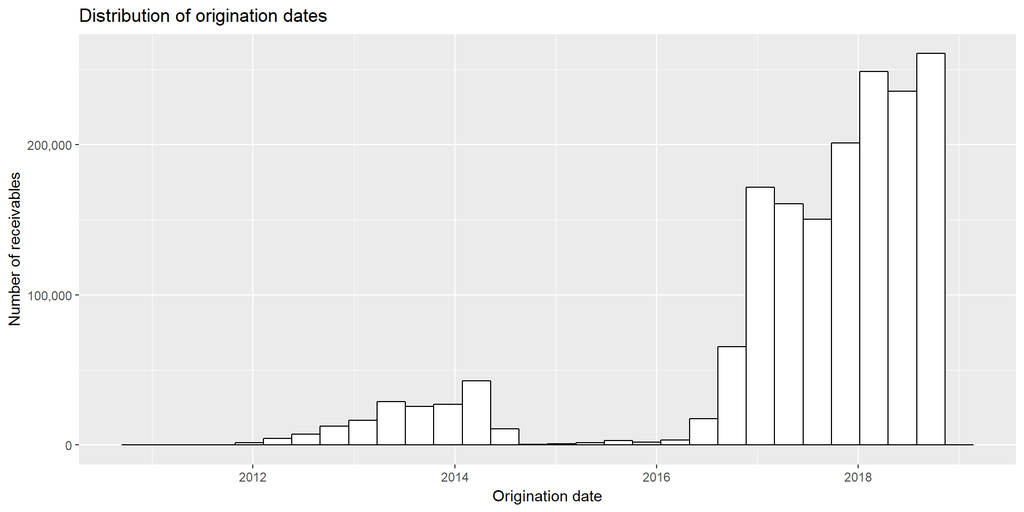

### Analysis

I will be looking specifically at how far or behind their payment schedule are the loans in this sample. To do this, I must first calculate what the expected principal balance should be at this point in time for any given loan. By then comparing the expected principal balance to the actual principal balance (a variable in the dataset), we can see if a borrower is ahead, behind (delinquent) or on time.

There is a variable in the filings, `currentDelinquencyStatus`, that shows the number of days a borrower is delinquent on their loan. In the sample, over 25 percent of the loans were at least one day delinquent.

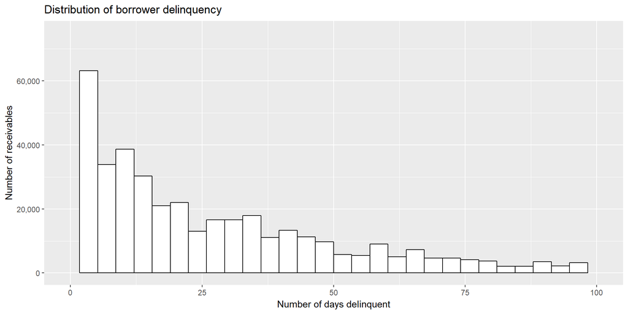

This does not however show how far behind the payment schedule the borrower is. For this, I will calculate the expected principal rate in the given month, in this case January, 2019, for all loans in the sample.

To calculate what the principal balance should be at a given date, I have created a function which uses the following variables from the dataset:

- original first payment date
- original loan term (months)
- original interest rate
- original loan amount

Given this info, the function calculates the principal amortization table and finds the remaining principal amount in the desired month, in this case January, 2019. It returns a dollar value which can be compared to the remaining principal amount variable from the dataset.

To apply the function to the 1.7 million loans in the sample, I ran it in parallel on my machine. The function performs some basic calculations in C++ to speed the compute time. Overall it took about eleven minutes to calculate the expected remaining principal amount for all 1.7 million loans in the sample.

#### Results

In the sample, I observe the following:

- 81,780 receivables began the period fully paid off
- An additional 41,541 were paid off in the reporting period
- 778,456 receivables had an expected ending principal balance at least $50 lower than their actual ending principal balance, meaning they have paid less than they should have
- 48,794 receivables were within five dollars of their expected principal balance

The following graph shows the distribution of *actual principal balance* minus *expected principal balance* for receivables with a non-zero principal balance at the end of the reporting period. The tails of this distribution are very long, with some receivables tens of thousands of dollars ahead or behind their expected balance, so the chart shows only within $1,000 of zero. This represents 1.3 of the 1.6 million receivables, roughly 81 percent.

Values have been rounded to the nearest dollar. The red line is highlighted to show which receivables’ expected balance exactly matches their actual balance.

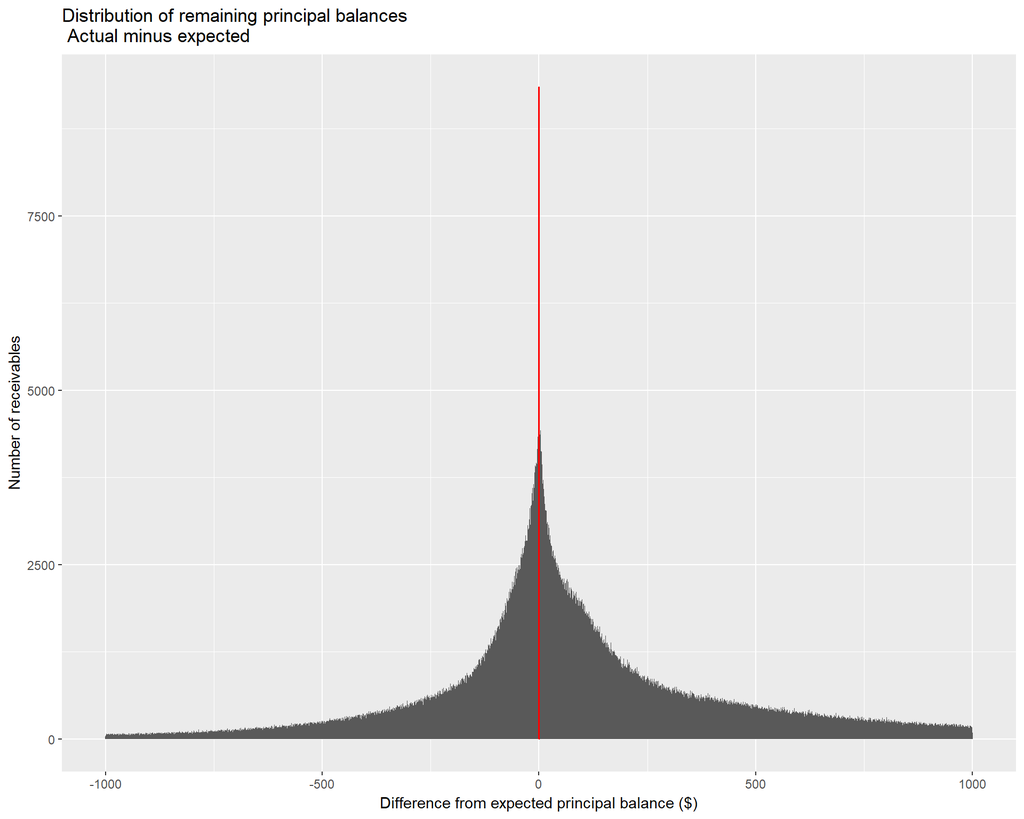

Based on the analysis, 931,147 out of 1,619,429 receivables are behind on their expected payments from the time of origination by at least one dollar.This is 57 percent.

This is quite a different figure than is shown by the `currentDelinquencyStatus` variable shown above, which indicated roughly 25 percent of loans to be delinquent. It may be worth exploring that further, but I remain confident in my amortization calculations at the loan-level and these results.

#### Behind-schedule receivables

Of the 900 thousand behind schedule payments, how far behind are the borrowers and at what point in the life of the loan are they?

Breaking the behind-schedule receivables into unequal buckets can help provide some idea of how severely behind schedule these borrowers are. For example, being behind schedule $80 is very different than being behind $1,000.

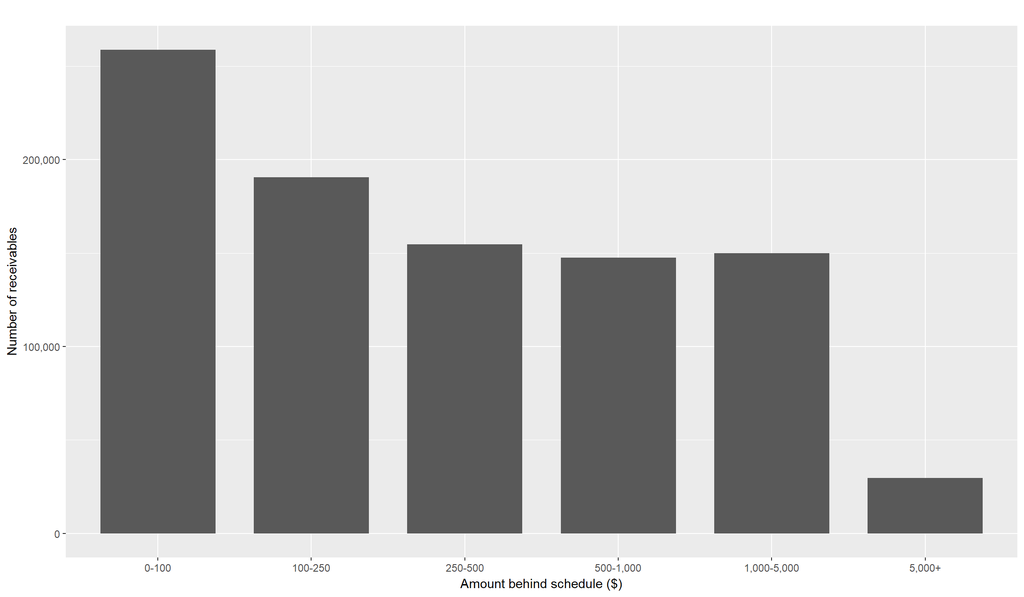

The below chart shows how far behind the receivables are by the number of months into the loan term.

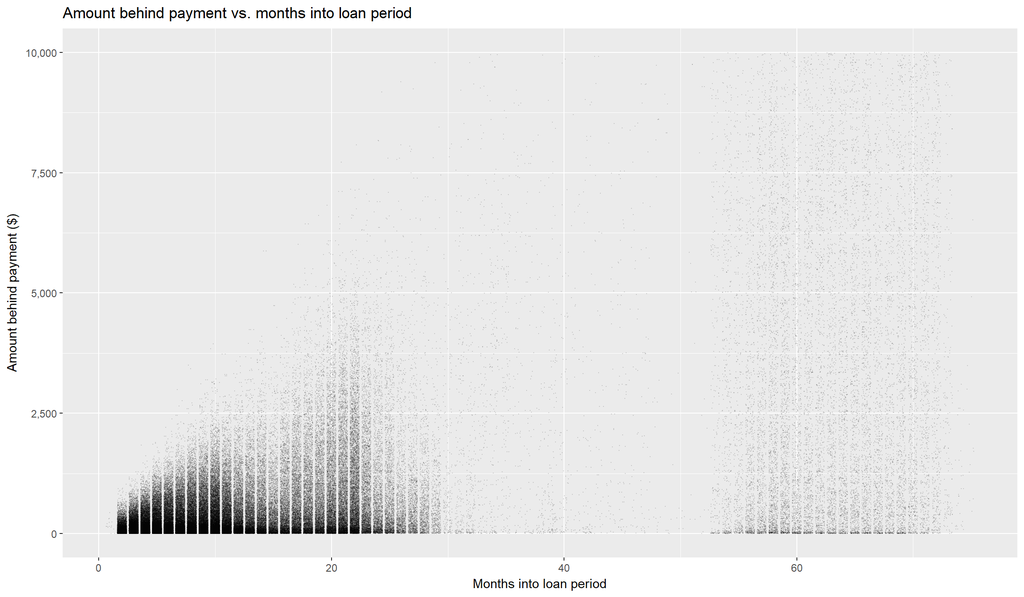

This chart reveals a significant number of loans are delinquent only a few months into their loan terms. Of the 33,836 loans originated in November 2018, 25,916 of them are already delinquent by some amount. Of these 33,000 loans, 218 have already paid off more than $10,000 more than expected. But of the 25,000 that have paid back less than expected, they averaged an underpayment in three months of $147.

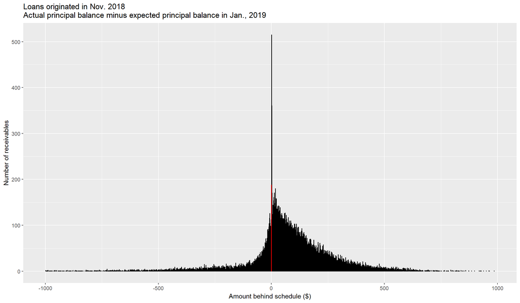

### Conclusion

It does appear that a significant number, over 50 percent, of the receivables in this sample of 1.6 million auto loans are behind their payment schedule at the time of loan origination. Looking further into the data, it would be worthwhile to generate a larger sample from a more diversified pool of lenders and compare the delinquency rates and severity with that of earlier dates, for example six months ago, one year ago, etc, to see how this metric has changed. Additionally, with significant computing resources one could examine the actual payments made by each receivable by downloading all monthly data for the loans, which would amount to billions of row of data across the 100-odd auto ABS transactions for which data is available for many months each.

It is also worth examining why the delinquency rates I calculated differ from those indicated in the data. One possible explanation is that terms were renegotiated and as such the borrower is not delinquent based on some new terms; my calculation is based off of the original loan terms found in the dataset.